# Dimension Reduction on Flow Cytometry Data

Yamkela Kwakwi

2024-10-24

# Visualization of flow cytometry data

In this part of the assignment we will use three dimension reduction techniques to visualize data in high dimension.

## Data Exploratory

```r
# Export libraries and read data

library(ggplot2)
library(tibble)
library(knitr)
library(dplyr)

dat <- read.csv("data/flow_cytometry_data.csv")
dat <- as.tibble(dat)
dat
```

```
## # A tibble: 100,000 × 19
##    major minor    cd3   cd4   cd8  cd19  cd20    cd16  cd56 cxcr3  ccr6  ccr4
##    <chr> <chr>  <dbl> <dbl> <dbl> <dbl> <dbl>   <dbl> <dbl> <dbl> <dbl> <dbl>
##  1 b     memory 0.938  1.51  1.93  5.48  5.90  1.87    1.68  1.71  2.44 1.72
##  2 b     memory 0.809  1.41  2.50  4.64  4.45  1.34    1.57  2.53  1.48 0.536
##  3 b     memory 1.50   2.14  2.18  4.56  5.57  2.50    1.87  2.22  1.90 3.10
##  4 b     memory 1.58   2.56  1.75  4.46  3.63  1.51    2.13  1.69  1.78 1.58
##  5 b     memory 1.78   1.86  1.45  5.11  4.37  2.24    1.81  1.52  2.30 1.59
##  6 b     memory 1.90   2.24  1.81  5.15  6.01 -0.0646  2.07  2.03  2.27 1.44
##  7 b     memory 2.42   1.12  2.71  4.14  5.55  3.78    2.75  1.68  2.07 1.42
##  8 b     memory 1.48   1.30  2.52  5.22  5.32  1.84    2.47  3.00  2.80 2.14
##  9 b     memory 1.33   1.84  1.62  4.50  5.21  2.26    3.09  2.06  2.24 2.54
## 10 b     memory 2.48   2.92  2.00  5.09  5.47  3.10    1.63  1.96  2.10 2.18
## # ℹ 99,990 more rows
## # ℹ 7 more variables: igd <dbl>, tcrgd <dbl>, va7.2 <dbl>, cd161 <dbl>,
## #   cd27 <dbl>, cd45ra <dbl>, ccr7 <dbl>
```

```r
# Check how many major cell types we have
unique(dat$major)
```

```
## [1] "b"     "cd4"   "cd8"   "mait"  "nk"    "tcrgd"
```

```r
# Check how many minor cell types we have
unique(dat$minor)
```

```
##  [1] "memory"         "naive"          "plasma"         "centralmemory"
##  [5] "effectormemory" "th1"            "th2"            "cytotoxic"
##  [9] "cd4+"           "cd8+"           "cd56+cd16-"     "cd56bright"
## [13] "cd56dim"        "vdelta1"        "vgamma9vdelta2"
```

The dataset is a 100 000 simulated cells. Each cell is classified into one of six cell groups: b, cd4, cd8, mait, nk, or tcrgd. Each group is further divided into subtypes such as memory, naive, plasma, centralmemory, effectormemory, th1, th2, cytotoxic, cd4+, cd8+, cd56+cd16-, cd56bright, cd56dim, vdelta1, and vgamma9vdelta2. The dataset contains expression levels of 17 different markers for these cells.

### Major and Minor cell count

```r
# Calculate the percatge abundance of each major_minor cell type

cell_count <- dat %>%
  group_by(major, minor) %>%
  summarise(count = n()) %>%
  mutate(major_minor = paste(major,minor, sep = "_"),
         percentage = (count/100000)*100) %>%
  mutate(percentage = round(percentage,2))   #round percantage to 2 decimals
cell_count <- cell_count[,-3]  # exclude the count variable

DT::datatable(cell_count)
```

|  | major | minor | major_minor | percentage |
| --- | --- | --- | --- | --- |
| 1 | b | memory | b_memory | 1.34 |
| 2 | b | naive | b_naive | 6.67 |
| 3 | b | plasma | b_plasma | 0.74 |
| 4 | cd4 | centralmemory | cd4_centralmemory | 9.39 |
| 5 | cd4 | effectormemory | cd4_effectormemory | 15.2 |
| 6 | cd4 | naive | cd4_naive | 12.4 |
| 7 | cd4 | th1 | cd4_th1 | 3.94 |
| 8 | cd4 | th2 | cd4_th2 | 5.36 |
| 9 | cd8 | centralmemory | cd8_centralmemory | 11.85 |
| 10 | cd8 | cytotoxic | cd8_cytotoxic | 4.13 |

[output cut: 9 more lines]

```r
# Check how many major_minor cell types we have
unique(cell_count$major_minor)
```

```
##  [1] "b_memory"             "b_naive"              "b_plasma"
##  [4] "cd4_centralmemory"    "cd4_effectormemory"   "cd4_naive"
##  [7] "cd4_th1"              "cd4_th2"              "cd8_centralmemory"
## [10] "cd8_cytotoxic"        "cd8_effectormemory"   "cd8_naive"
## [13] "mait_cd4+"            "mait_cd8+"            "nk_cd56+cd16-"
## [16] "nk_cd56bright"        "nk_cd56dim"           "tcrgd_vdelta1"
## [19] "tcrgd_vgamma9vdelta2"
```

```r
# Add the major_minor variable to the dat
dat <- dat %>%
  mutate(major_minor = paste(major,minor, sep = "_"))

# Subset the dat to 1k observations for test runs
dat_subset <- dat %>% sample_n(10000)
```

## Data prep

### For applying dimension reduction techinique

```r
# Convert to matrix excluding 'major' and 'minor' columns
mat_dat <- as.matrix(dat %>% select(-major, -minor, -major_minor))

# Select the categorical data
cat_dat <- dat %>% select(major_minor,major,minor)
```

### For plotting

```r
library(cowplot)
library(ggrepel)
library(RColorBrewer)

col_vec_bcell <- c("#c5e1a5", "#aed581", "#9ccc65")

col_vec_cd4 <- c("#b3d1ff", "#a3c1da", "#87bdd8", "#6fa3c1", "#00509e")

col_vec_cd8 <- c("#ffcccb", "#ffb3ba", "#ff9999", "#ff8080")

col_vec_mait <- c("#dab3ff", "#c299ff")

col_vec_nk <- c("#ffe4b3", "#ffd699", "#ffc266")

col_vec_tcrgd <- c("#d3d3d3", "#696969")



display_tbl <- cell_count %>%
  mutate(n_all = n()) %>%
  group_by(major) %>%
  mutate(n_major = n()) %>%
  ungroup() %>%
  select(major_minor, major, minor, n_all, n_major) %>%
  group_by(major_minor, major, minor) %>%
  summarise(
    perc_all = (n()/n_all[1]*100) %>% signif(2),
    perc_major = (n()/n_major[1]*100) %>%  signif(2),
    .groups = "drop"
  ) %>%
  ungroup() %>%
  mutate(
    col_minor = c(col_vec_bcell, col_vec_cd4, col_vec_cd8, col_vec_mait, col_vec_nk, col_vec_tcrgd),
    col_major = c(
      rep(col_vec_bcell[2],3),
      rep(col_vec_cd4[3],5),
      rep(col_vec_cd8[2],4),
      rep(col_vec_mait[2],2),
      rep(col_vec_nk[2],3),
      rep(col_vec_tcrgd[2],2)
    )
  ) %>%

  mutate(
    shape_minor = c(15:17, c(15:18,25), c(15:18), c(15:16), c(15:17), c(15:16)),
    shape_major = c(
      rep(15,3),
      rep(16,5),
      rep(17,4),
      rep(18,2),
      rep(25,3),
      rep(10,2)

    )
  ) %>%
  select(major_minor, major, minor, col_major, col_minor, shape_major, shape_minor, perc_all, perc_major)

col_lab_minor <- display_tbl$col_major %>%
  stats::setNames(display_tbl$major_minor)
shape_lab_minor <- display_tbl$shape_minor %>%
  stats::setNames(display_tbl$major_minor)

display_tbl_major <- display_tbl %>%
  group_by(major) %>%
  slice(1) %>%
  ungroup()

col_lab_major <- display_tbl_major$col_major %>%
  stats::setNames(display_tbl_major$major)
shape_lab_major <- display_tbl_major$shape_major %>%
  stats::setNames(display_tbl_major$major)
```

## PCA

The first dimensionality reduction technique we used is Principal Component Analysis (PCA). PCA transforms the original data into a set of linearly uncorrelated variables called principal components.

### Perform dimension reduction

```r
start_time <- Sys.time()
pca <- prcomp(mat_dat, center = T, scale. = F) # apply PCA
end_time <- Sys.time()

# Calculate time it takes to run the PCA
pca_tot_time <-  as.numeric(end_time - start_time)

# Store the first two principal components
pca_1 <- pca$x[, 1]
pca_2 <- pca$x[, 2]

# Calculate total variance explained by the 1st two prcomp
var_explained <- summary(pca)$importance[2, 1:2]
var_explained
```

```
##     PC1     PC2
## 0.23326 0.21710
```

```r
total_var_explained <- sum(var_explained)
total_var_explained
```

```
## [1] 0.45036
```

```r
# Total variance explained by the first two principal components
total_variance_explained <- sum(var_explained)
total_variance_explained
```

```
## [1] 0.45036
```

```r
# Ceate a tibble
pca_tibble <- cat_dat %>%
  mutate(pc1 = pca_1,
         pc2 = pca_2,
         pca_time = pca_tot_time)

pca_tibble <- as.tibble(pca_tibble)
pca_tibble
```

```
## # A tibble: 100,000 × 6
##    major_minor major minor    pc1   pc2 pca_time
##    <chr>       <chr> <chr>  <dbl> <dbl>    <dbl>
##  1 b_memory    b     memory -3.97 -3.49    0.191
##  2 b_memory    b     memory -3.19 -2.18    0.191
##  3 b_memory    b     memory -3.00 -2.84    0.191
##  4 b_memory    b     memory -1.61 -2.53    0.191
##  5 b_memory    b     memory -2.94 -3.29    0.191
##  6 b_memory    b     memory -2.38 -3.09    0.191
##  7 b_memory    b     memory -3.45 -1.69    0.191
##  8 b_memory    b     memory -3.25 -2.05    0.191
##  9 b_memory    b     memory -3.58 -3.23    0.191
## 10 b_memory    b     memory -2.55 -3.17    0.191
## # ℹ 99,990 more rows
```

### Plot both major and minor cell types and for each cell population

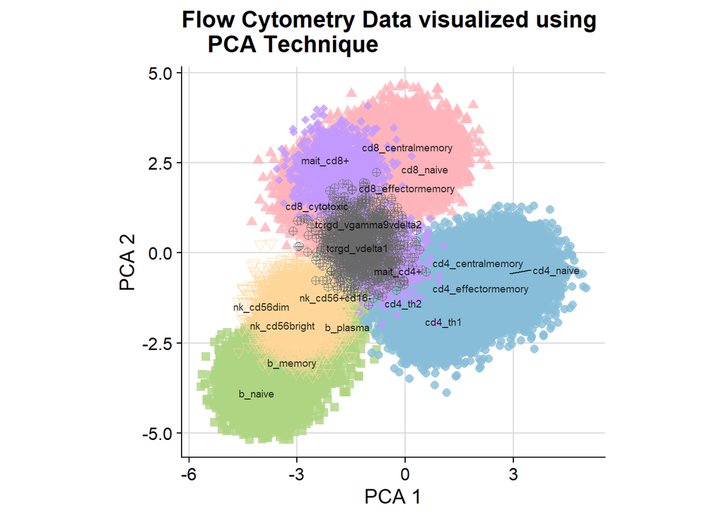

```r
# Plot for both major and minor cell types in one plot

p1_pca <- ggplot(pca_tibble, aes(x = pc1, y = pc2))+
  theme_cowplot()+
  background_grid(major = "xy")+
  geom_point(aes(colour = major_minor, shape = major),
             size = 2.5, alpha = 0.8) +
  scale_color_manual(values = col_lab_minor)+
  scale_shape_manual(values = shape_lab_major)+
  geom_text_repel(
    data = pca_tibble %>%
      group_by(major_minor, major, minor) %>%
      summarise(pca1_mean = mean(pc1),
                pca2_mean = mean(pc2),
                .groups = "drop"),
    aes(x = pca1_mean, y = pca2_mean, label = major_minor),
    size = 2.5, alpha = 0.8, inherit.aes = F, max.overlaps = 100) +
  theme(legend.position = "botttom") +
  labs(
    title = "Flow Cytometry Data visualized using
    PCA Technique",
    x = "PCA 1",
    y = "PCA 2",
    color = "Cell type",
    shape = "Major Cell Type") +
  coord_equal()

p1_pca
```

```r
ggsave("img/pca.jpg", plot = p1_pca, width = 10, height = 8)
```

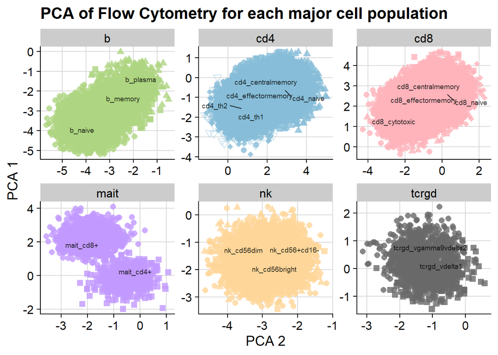

```r
# Facet for the different major cell types: "b"     "cd4"   "cd8"   "mait"  "nk"    "tcrgd"

p2_pca <- ggplot(pca_tibble, aes(x=pc1, y = pc2))+
  theme_cowplot()+
  background_grid(major = "xy")+
  geom_point(
    aes(colour = major_minor, shape = major_minor),
    size = 2.5, alpha = 0.8
  )+
  scale_color_manual(values = col_lab_minor)+
  scale_shape_manual(values = shape_lab_minor)+
  geom_text_repel(
    data = pca_tibble %>%
      group_by(major_minor, major) %>%
      summarise(pca1_mean = mean(pc1),
                pca2_mean = mean(pc2),
                .groups = "drop"),
    aes(x = pca1_mean, y = pca2_mean, label = major_minor),
    size = 2.5, alpha = 0.8, inherit.aes = FALSE, max.overlaps = 100)+
  facet_wrap(~major, ncol = 3, scales = "free")+
  labs(
    title = "PCA of Flow Cytometry for each major cell population",
    y = "PCA 1",
    x = "PCA 2",
    color = "Cell type",
    shape = "Major Cell type"
  )+
  theme(legend.position = "none")


p2_pca
```

```r
ggsave("img/pca_facet.jpg", plot = p2_pca, width = 10, height = 8)
```

The PCA algorithm performs well at separating the major cell types, such as b, cd4, cd8, mait, nk, and tcrgd, showing clear distinctions between them. However, there is significant overlap between the subtypes, making it challenging to differentiate between them in the 2D plot. Notably, the algorithm struggles with distinguishing subtypes, except for the mait cells. Specifically, mait cd8+ cells are clustered closer to the cd8 cell types, while mait cd4+ cells are pulled towards the cd4 cell types, indicating that these subtypes share similar principal components with the larger cell types they are associated with. This suggests that PCA may not be capture the finer, more complex relationships needed to separate these subtypes effectively.

## MDS

### Perform dimension reduction

```r
dat_subset <- dat %>% sample_n(10000) # for MDS we used a subset of 1000 observation because of scalability limitations

# Convert to matrix excluding 'major' and 'minor' columns
mat_subset <- as.matrix(dat_subset %>% select(-major, -minor, -major_minor))

# Select the categorical data
cat_subset <- dat_subset %>% select(major_minor,major,minor)


distance_matrix <- dist(mat_subset)

start_time <- Sys.time()
mds_result <- cmdscale(distance_matrix, k = 2)
end_time <- Sys.time()

# Calculate time it takes to run MDS
mds_tot_time <- as.numeric(end_time - start_time)

mds_1 <- mds_result[, 1]
mds_2 <- mds_result[, 2]

# Create a tibble with MDS results
mds_tibble <- cat_subset %>%
  mutate(mds1 = mds_1,
         mds2 = mds_2,
         mds_time = mds_tot_time)

mds_tibble <- as.tibble(mds_tibble)
mds_tibble
```

```
## # A tibble: 10,000 × 6
##    major_minor        major minor            mds1   mds2 mds_time
##    <chr>              <chr> <chr>           <dbl>  <dbl>    <dbl>
##  1 cd4_naive          cd4   naive           2.54  -1.02      27.9
##  2 nk_cd56+cd16-      nk    cd56+cd16-     -2.80  -0.976     27.9
##  3 nk_cd56bright      nk    cd56bright     -2.47  -0.663     27.9
##  4 cd4_effectormemory cd4   effectormemory  0.648 -2.00      27.9
##  5 cd4_effectormemory cd4   effectormemory  1.45  -2.22      27.9
##  6 nk_cd56dim         nk    cd56dim        -3.03  -0.492     27.9
##  7 cd8_centralmemory  cd8   centralmemory  -1.01   2.45      27.9
##  8 cd8_centralmemory  cd8   centralmemory   0.633  3.62      27.9
##  9 mait_cd8+          mait  cd8+           -1.44   2.40      27.9
## 10 cd8_effectormemory cd8   effectormemory -2.03   2.85      27.9
## # ℹ 9,990 more rows
```

### Plot both major and minor cell types and for each cell type

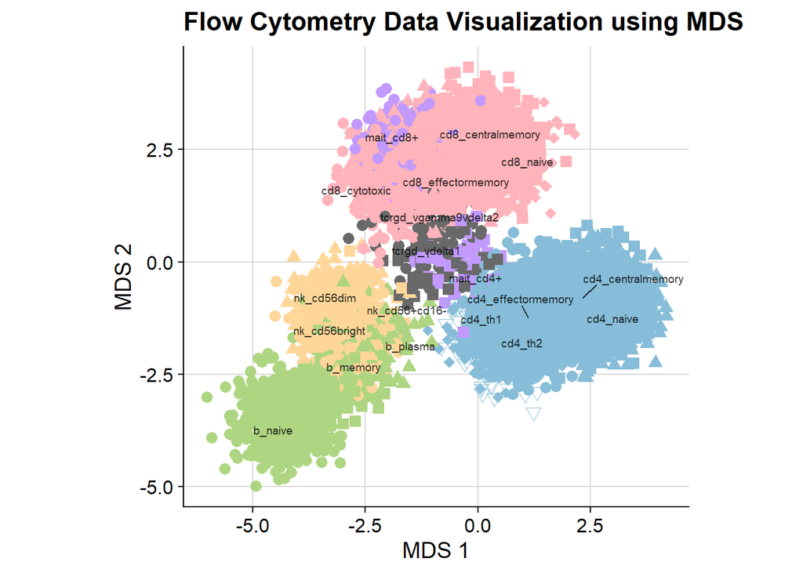

```r
# Plot the MDS results
p1_mds <- ggplot(mds_tibble, aes(x = mds1, y = mds2)) +
  theme_cowplot()+
  background_grid(major = "xy")+
  geom_point(aes(color = major_minor, shape = major_minor), size = 3) +
  scale_color_manual(values = col_lab_minor) +
  scale_shape_manual(values = shape_lab_major)+
  geom_text_repel(
    data = mds_tibble %>%
      group_by(major_minor, major, minor) %>%
      summarise(mds1_mean = mean(mds1),
                mds2_mean = mean(mds2),
                .groups = "drop"),
    aes(x = mds1_mean, y = mds2_mean, label = major_minor),
    size = 2.5, alpha = 0.8, inherit.aes = F, max.overlaps = 100) +
  theme(legend.position = "botttom") +
  scale_shape_manual(values = shape_lab_minor) +
  labs(
    title = "Flow Cytometry Data Visualization using MDS",
    x = "MDS 1",
    y = "MDS 2",
    color = "Cell type",
    shape = "Major Cell type"
  ) +
  coord_equal()
p1_mds
```

```r
ggsave("img/mds.jpg", plot = p1_mds, width = 10, height = 8)
```

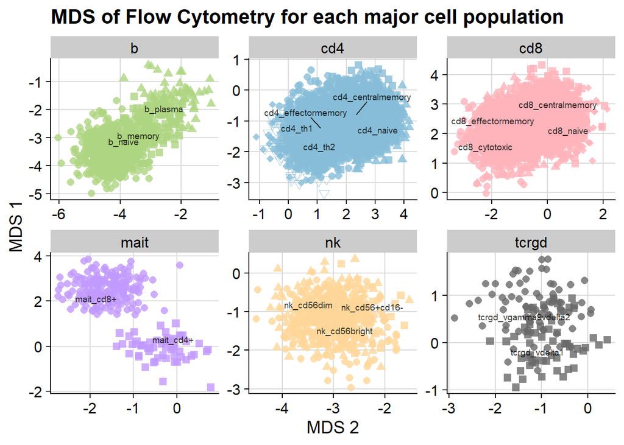

```r
# Faceted MDS plot based on the "major" cell types
p2_mds <- ggplot(mds_tibble, aes(x = mds1, y = mds2)) +
  theme_cowplot() +
  background_grid(major = "xy") +
  geom_point(
    aes(colour = major_minor, shape = major_minor),
    size = 2.5, alpha = 0.8
  ) +
  scale_color_manual(values = col_lab_minor) +
  scale_shape_manual(values = shape_lab_minor) +
  geom_text_repel(
    data = mds_tibble %>%
      group_by(major_minor, major) %>%
      summarise(mds1_mean = mean(mds1),
                mds2_mean = mean(mds2),
                .groups = "drop"),
    aes(x = mds1_mean, y = mds2_mean, label = major_minor),
    size = 2.5, alpha = 0.8, inherit.aes = FALSE, max.overlaps = 100
  ) +
  facet_wrap(~major, ncol = 3, scales = "free") +
  labs(
    title = "MDS of Flow Cytometry for each major cell population",
    y = "MDS 1",
    x = "MDS 2",
    color = "Cell type",
    shape = "Major Cell type"
  ) +
  theme(legend.position = "none")


p2_mds
```

```r
ggsave("img/mds_facet.jpg", plot = p2_mds, width = 10, height = 8)
```

Despite the limitations, MDS, like PCA, performed well in separating the major cell types. However, it also struggled with separating the subtypes. MDS did slightly better than PCA in this regard, as it showed clearer separation of the mait subtypes and some separation of the tcrgd subtypes, although not as distinct. Additionally, there was a slight distinction between the three b cell subtypes.

## UMAP

### Perform dimension reduction

```r
library(uwot)
# Apply UMAP instead of PCA
start_time <- Sys.time()
umap_res <- umap(mat_dat,
                 n_neighbors = 15,
                 n_components = 2,
                 min_dist = 2)
end_time <- Sys.time()

# Calculate the time it takes to run UMAP
umap_tot_time <- as.numeric(end_time - start_time)

# Store the UMAP dimensions
umap_1 <- umap_res[, 1]
umap_2 <- umap_res[, 2]

# Create a tibble similar to how you did for PCA
umap_tibble <- cat_dat %>%
  mutate(umap1 = umap_1,
         umap2 = umap_2,
         umap_time = umap_tot_time)

# Convert to tibble if needed
umap_tibble <- as.tibble(umap_tibble)
umap_tibble
```

```
## # A tibble: 100,000 × 6
##    major_minor major minor  umap1 umap2 umap_time
##    <chr>       <chr> <chr>  <dbl> <dbl>     <dbl>
##  1 b_memory    b     memory -16.8 10.8       1.72
##  2 b_memory    b     memory -18.5  7.93      1.72
##  3 b_memory    b     memory -19.2 11.1       1.72
##  4 b_memory    b     memory -17.6  7.12      1.72
##  5 b_memory    b     memory -18.7  8.64      1.72
##  6 b_memory    b     memory -19.7  8.78      1.72
##  7 b_memory    b     memory -20.9  8.79      1.72
##  8 b_memory    b     memory -19.9 10.3       1.72
##  9 b_memory    b     memory -18.8  9.66      1.72
## 10 b_memory    b     memory -19.2 10.3       1.72
## # ℹ 99,990 more rows
```

### Plot both major and minor cell types and for each cell type

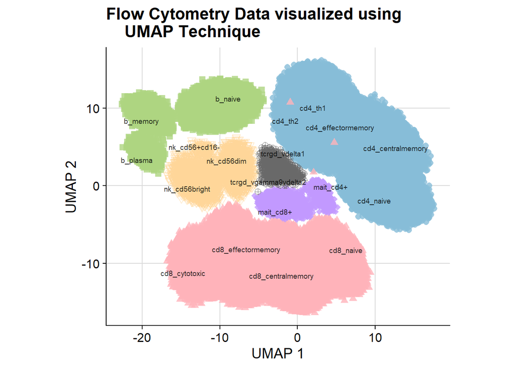

```r
p1_umap <- ggplot(umap_tibble, aes(x = umap1, y = umap2))+
  theme_cowplot()+
  background_grid(major = "xy")+
  geom_point(aes(colour = major_minor, shape = major),
             size = 2.5, alpha = 0.8) +
  scale_color_manual(values = col_lab_minor)+
  scale_shape_manual(values = shape_lab_major)+
  geom_text_repel(
    data = umap_tibble %>%
      group_by(major_minor, major, minor) %>%
      summarise(umap1_mean = mean(umap1),
                umap2_mean = mean(umap2),
                .groups = "drop"),
    aes(x = umap1_mean, y = umap2_mean, label = major_minor),
    size = 2.5, alpha = 0.8, inherit.aes = F, max.overlaps = 100) +
  theme(legend.position = "botttom") +
  labs(
    title = "Flow Cytometry Data visualized using
    UMAP Technique",
    x = "UMAP 1",
    y = "UMAP 2",
    color = "Cell type",
    shape = "Major Cell Type") +
  coord_equal()

p1_umap
```

```r
ggsave("img/umap.jpg", plot = p1_umap, width = 10, height = 8)
```

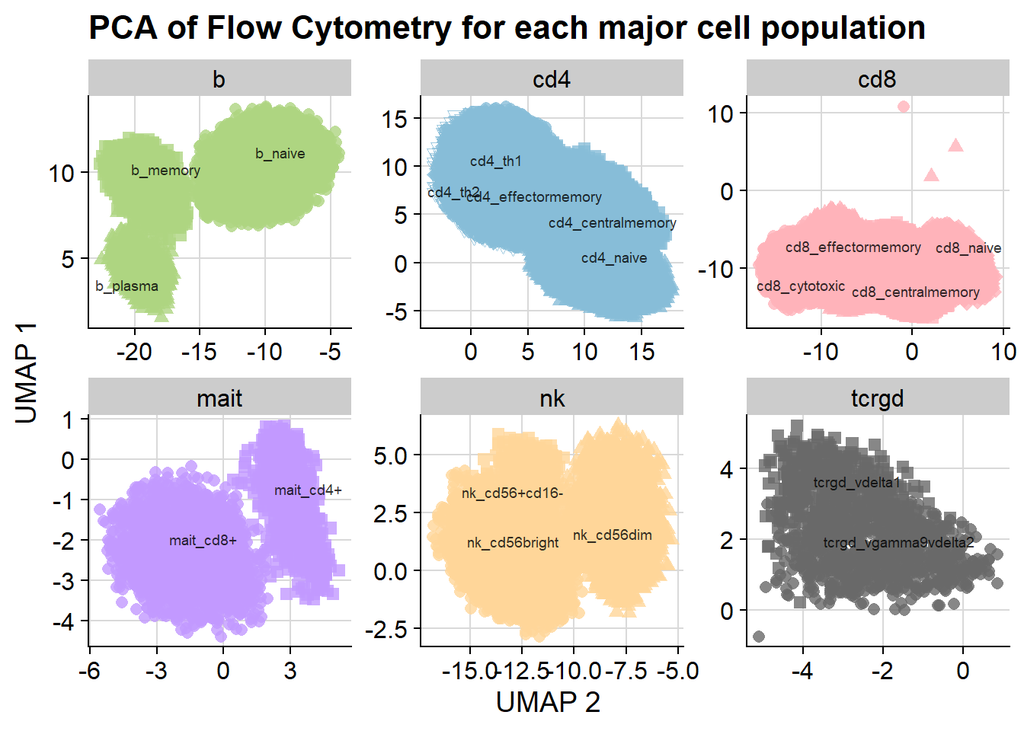

```r
# Facet for the different major cell types: "b"     "cd4"   "cd8"   "mait"  "nk"    "tcrgd"


p2_umap <- ggplot(umap_tibble, aes(x=umap1, y = umap2))+
  theme_cowplot()+
  background_grid(major = "xy")+
  geom_point(
    aes(colour = major_minor, shape = major_minor),
    size = 2.5, alpha = 0.8
  )+
  scale_color_manual(values = col_lab_minor)+
  scale_shape_manual(values = shape_lab_minor)+
  geom_text_repel(
    data = umap_tibble %>%
      group_by(major_minor, major) %>%
      summarise(umap1_mean = mean(umap1),
                umap2_mean = mean(umap2),
                .groups = "drop"),
    aes(x = umap1_mean, y = umap2_mean, label = major_minor),
    size = 2.5, alpha = 0.8, inherit.aes = FALSE, max.overlaps = 100)+
  facet_wrap(~major, ncol = 3, scales = "free")+
  labs(
    title = "PCA of Flow Cytometry for each major cell population",
    y = "UMAP 1",
    x = "UMAP 2",
    color = "Cell type",
    shape = "Major Cell type"
  )+
  theme(legend.position = "none")

p2_umap
```

```r
# Save the plot to the current working directory
ggsave("img/umap_facet.jpg", plot = p2_umap, width = 10, height = 8)
```

The last technique we used was UMAP (Uniform Manifold Approximation and Projection), which works by preserving the local structure of high-dimensional data while creating a lower-dimensional projection.

However, UMAP struggled with the tcrgd subtypes, which showed significant overlap, possibly due to a lack of distinct marker expression patterns within these subtypes. The separation of cd4 and cd8 cells was not as clear, likely due to their abundance and the larger number of subtypes (5 for cd4 and 4 for cd8). In the cd8 cell types, all the subtypes seemed to be perfectly aligned along the first UMAP component, suggesting that key distinctions between the subtypes might be captured in a different dimension than the fist two components.

## Conclusion

The dimensionality reduction techniques demonstrated strengths and weaknesses in visualizing the cell types and subtypes in the dataset:

PCA: Strengths lie in its speed.. It performed well in separating major cell types but struggled with fine-grained subtype separation. Its linear nature limited its ability to capture more complex relationships.

MDS: While effective at preserving pairwise distances and slightly better than PCA in distinguishing some subtypes (especially mait and b cells), MDS was impractical for large datasets due to its memory requirements. The improved separation in subtypes could also be influenced by the reduced sample size used.

Overall, UMAP proved to be the most effective, while PCA was the fastest, and MDS was hindered by scalability issues.